# Enriched binding sites definition

Melina Klostermann

12 September, 2023

# 1 Libraries and settings

```r
# ----------------------------------------
# libraries
# ----------------------------------------

library(rtracklayer)
library(GenomicRanges)
library(ggplot2)
library(dplyr)
library(reshape2)
library(GenomicFeatures)
library(BindingSiteFinder)
library(ComplexHeatmap)
library(tibble)
library(tidyr)
library(dplyr)
library(ggrepel)
library(ggpointdensity)
library(purrr)
library(Biostrings)
library(BSgenome.Mmusculus.UCSC.mm10)
library(knitr)
library(kableExtra)

here <- here::here()

source(paste0(here,"/Supporting_scripts/themes/theme_paper.R"))

# ----------------------------------------
# settings
# ----------------------------------------

out <- paste0(here,"/Figure2+SF1h-j/01_mir181-enriched_binding_site_definition")
```

# 2 Functions

```r
# ----------------------------------------
# utility functions
# ----------------------------------------

basicVectorToNiceDf <- function(x){
  # NOTE MK you could do all starting from the 3. line in one mutate command, might be faster and easier to read?
  df = data.frame(Type = names(table(x$olType)), Freq = as.vector(table(x$olType)))
  df = df[order(df$Freq, decreasing = F),]
  df$Type = factor(df$Type, levels = df$Type)
  df$Frac = df$Freq / sum(df$Freq)
  df$ymax = cumsum(df$Frac)
  df$ymin = c(0, head(df$ymax, n=-1))
  df$labPos = (df$ymax + df$ymin) / 2
  df$NFrac = round(df$Frac * 100)
  df$NFrac2 = round(df$Freq / sum(df$Freq), digits = 4)
  df$NFracNice = df$NFrac2 * 100
  df$labelNice = paste0(format(df$Freq, big.mark = ",", decimal.mark = "."), " (", df$NFracNice, "%)")
  df$labelNice2 = paste0(df$Type, ": ", format(df$Freq, big.mark = ",", decimal.mark = "."), " (", df$NFracNice, "%)")
  return(df)
}
```

# 3 What was done?

*NOTE*: Large parts of code and text are from the BindingSiteFinder Vignette. For a detailed explanaition see https://www.bioconductor.org/packages/release/bioc/vignettes/BindingSiteFinder/inst/doc/vignette.html

# 4 Files

## 4.1 Merge crosslinks of chimeric and non-chimeric reads

Here we use a merge of the chimeric and non-chimeric crosslinks from the enriched mir181 data. .bw files from chimeric and non-chimeric reads which are outputed from Raccon are merged in the commandline with uscs-bigWigMerge.

```bash
# ----------------------------------------
# Merge bw non-chimeric and chimeric sample wise
# ----------------------------------------

bigWigMerge crosslinks_chimeric_sampleX.bw crosslinks_non-chimeric_sampleX.bw crosslinks_mixed_sampleX.bed

LC_COLLATE=C sort -k1,1 -k2,2n -k3,3n crosslinks_mixed_sampleX.bed -o crosslinks_mixed_sampleX.sort.bed

bedGraphToBigWig crosslinks_mixed_sampleX.sort.bed GRCm38.p6.genome.fa.fai  crosslinks_mixed_sampleX.sort.bw
```

## 4.2 Merge bam files run pureclip

We use the peakcaller pureclip to detect crosslink peaks. pureclip is run on the merge of the three samples with both chimeirc and non-chimeric crosslinks.

```bash
# ----------------------------------------
# Merge bam non-chimeric and chimeric (all samples together)
# ----------------------------------------

samtools merge -o crosslinks_mixed_all_samples.bam crosslinks_chimeric_all_samples.bamm crosslinks_non-chimeric_samples.bam
samtools sort crosslinks_mixed_all_samples.bam crosslinks_mixed_all_samples.sort.bam
samtools index crosslinks_mixed_all_samples.sort.bam

# ----------------------------------------
# Run pureclip
# ----------------------------------------

pureclip \
-i crosslinks_mixed_all_samples.sort.bam\
-bai crosslinks_mixed_all_samples.sort.bam.bai \
-g GRCm38.p6.genome.strict.IUPAC.fa \
-nt 10 \
-o mixed_IP_WT_miR181_pureclip_sites_230323.bed \
```

```r
# ----------------------------------------
# ----------------------------------------
# Files
# ----------------------------------------
# ----------------------------------------

# ----------------------------------------
# annotation
# ----------------------------------------

annoDb <- loadDb(paste0(here,"/Supporting_scripts/annotation_preprocessing/annotation.db"))
gns <- readRDS(paste0(here,"/Supporting_scripts/annotation_preprocessing/gene_annotation.rds"))

# ----------------------------------------
# pureclip sites (from peak calling)
# ----------------------------------------
pureclip_sites <- "/Users/melinaklostermann/Documents/projects/AgoCLIP_miR181/pureclip/mixed_IP_WT_miR181_pureclip_sites_230323.bed"

# ----------------------------------------
# crosslinks
# ----------------------------------------

# crosslinks mixed  chimeric, non-chimeric
clipFiles = "/Users/melinaklostermann/Documents/projects/AgoCLIP_miR181/pipe_output_22_02_14/chimeric/crosslinks_mixed"
clipFiles = list.files(clipFiles, pattern = ".bw$", full.names = TRUE)
clipFiles  = clipFiles[!grepl("Inp", clipFiles)]
clipFiles  = clipFiles[grepl("miR181_", clipFiles)]
clipFiles  = clipFiles[grepl("WT", clipFiles)]
clipFilesP  = clipFiles[grep(clipFiles, pattern = "plus")]
clipFilesM  = clipFiles[grep(clipFiles, pattern = "minus")]
```

# 5 Obtained pureclip sites (from peak calling)

```r
# ----------------------------------------
# Get and clean pureclip sites
# ----------------------------------------

pureclip_sites <- import.bedGraph(pureclip_sites)
pureclip_sites = as.data.frame(pureclip_sites)
pureclip_sites$score =  pureclip_sites$NA.
pureclip_sites$strand = pureclip_sites$NA..1
pureclip_sites$NA. = NULL
pureclip_sites$NA..1 = NULL
pureclip_sites$NA..2 = NULL
pureclip_sites = makeGRangesFromDataFrame(pureclip_sites, keep.extra.columns = T)
pureclip_sites = keepStandardChromosomes(pureclip_sites, pruning.mode = "coarse")

kable(head(pureclip_sites)) %>%
  kable_material(c("striped", "hover"))
```

seqnames

start

end

width

strand

score

chr1

6240152

6240152

1

0.976837

chr1

6240153

6240153

1

0.563029

chr1

6244795

6244795

1

0.461608

chr1

6244796

6244796

1

0.607505

chr1

6248280

6248280

1

1.300870

chr1

6248281

6248281

1

0.878214

–> Number of pureclip sites: 33930

# 6 Compute binding sites

## 6.1 Settings for binding sites

```r
# -------------------------------
# set BS final options
# -------------------------------
bsSize_Final = 7
minWidth_Final = 2
minCrosslinks_Final = 2
minClSites_Final = 2
```

## 6.2 Make BindingSiteFinder object

```r
# -------------------------------------------------------
# Organize clip data in dataframe for binding site finder
# -------------------------------------------------------

colData= data.frame(
  id = c(1:3),
  condition = factor(c("WT", "WT", "WT"),
                     levels = c("WT")),
                     clPlus = clipFilesP  ,
                     clMinus = clipFilesM)

# Make BindingSiteFinder object
bds = BSFDataSetFromBigWig(ranges = pureclip_sites, meta = colData)
bds
```

```
## Object of class BSFDataSet
## Contained ranges:  33.930
## ----> Number of chromosomes:  22
## ----> Ranges width:  1
## Contained Signal: 5,156,221
## Contained conditions:  WT
```

## 6.4 Make binding sites

```r
# -------------------------------------------------------
# Make  binding sites
# -------------------------------------------------------
bds_sites <- makeBindingSites(object = bds, bsSize = bsSize_Final, minWidth = minWidth_Final,
                        minCrosslinks = minCrosslinks_Final, minClSites = minClSites_Final)

bds_sites
```

```
## Object of class BSFDataSet
## Contained ranges:  7.809
## ----> Number of chromosomes:  22
## ----> Ranges width:  7
## Contained Signal: 5,156,221
## Contained conditions:  WT
```

```r
# make GrangesObject of binding sites
bds_sites_gr = getRanges(bds_sites)
bds_sites_gr
```

```
## GRanges object with 7809 ranges and 0 metadata columns:
##        seqnames          ranges strand
##           <Rle>       <IRanges>  <Rle>
##      1     chr1 6240149-6240155      +
##      2     chr1 6244793-6244799      +
##      3     chr1 6248277-6248283      +
##      4     chr1 6248959-6248965      +
##      5     chr1 6249310-6249316      +
##    ...      ...             ...    ...
##   8496     chrM     14296-14302      +
##   8497     chrM     15351-15357      +
##   8498     chrM       3842-3848      -
##   8499     chrM       5257-5263      -
##   8500     chrM     16189-16195      -
##   -------
##   seqinfo: 22 sequences from an unspecified genome; no seqlengths
```

```r
df = getSummary(bds_sites)
kable(df)  %>%
  kable_material(c("striped", "hover"))
```

| Option | nRanges |
| --- | --- |
| inputRanges | 33930 |
| mergeCrosslinkSites | 8729 |
| minCrosslinks | 8084 |
| minClSites | 7930 |
| centerIsClSite | 7925 |
| centerIsSummit | 7809 |

## 6.5 Reproducibility filter

Since peak calling is based on the merge of all replicates, we filter processed binding site for their support by the individual replicates. First, crosslinks are summed up per replicate creating a crosslink distribution. Then, a threshold is set for each replicate to the 5% quantile of that distribution. To account for low crosslink replicates, a lower boundary of 1 crosslink events per binding site is enforced.

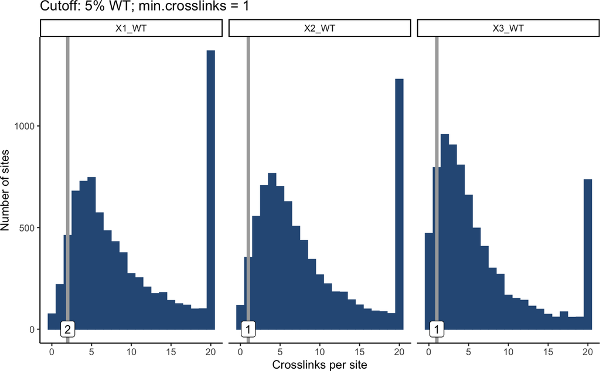

```r
# -------------------------------------------------------
# Check reproducibility cutoff
# Supplementary Figure 1 h
# -------------------------------------------------------

p <- reproducibiliyCutoffPlot(bds_sites, max.range = 20, cutoff = 0.05)

p
```

```r
p <- p + theme_paper()
ggsave(p, filename = paste0(out, "FigureS1J_BS_enriched_repro_cutoff.pdf"), width = unit(12, "cm"), height = unit(4,"cm"))
```

Finally, a binding sites is deemed reproducible if the thresholds are met for all two of three replicates. The Upset plot below shows the support intersections of the three samples for the binding sites.

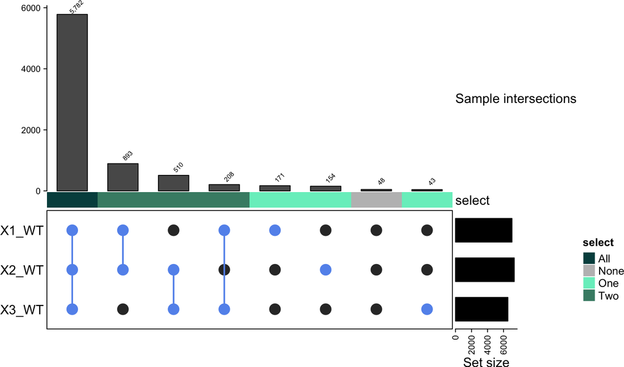

```r
# -------------------------------------------------------
# Check reproducibility of binding sites between the three non-chimeric and the three chimeric samples
# Supplementary Figure 1 i
# -------------------------------------------------------
s1 = reproducibilityFilter(bds_sites, cutoff = 0.05, n.reps = 2, returnType = "data.frame")
m = make_comb_mat(s1, mode = "distinct")

df = strsplit(names(comb_degree(m)), "")
df = do.call(rbind,df)
df = as.matrix(df)
df = apply(df, 2, as.numeric)
df = as.data.frame(df)

df$support = rowSums(df)
rownames(df) = names(comb_degree(m))


df$status = ifelse(df$support == 3, "All",
                                        ifelse(df$support == 2, "Two",
                                               ifelse(df$support == 1, "One", "None")))


# plot Upset with Complex Heatmap package
ha = HeatmapAnnotation(
  col = list(select = c("All" = "#004d4d",  "Two" = "aquamarine4", "One" = "aquamarine2", "None" = "grey")),
  "Sample intersections" = anno_barplot(comb_size(m), border = FALSE, gp = gpar(fill = "#595959"), height = unit(6, "cm")),
    select = df$status
)

ht = UpSet(m,
           set_order = colnames(s1),
           comb_order = order(comb_size(m), decreasing = T),
           top_annotation = ha,
           comb_col = "cornflowerblue", bg_col = "white", pt_size = unit(.5, "cm") ,
           border = T, lwd = 2, bg_pt_col = "#333333"
)

ss = set_size(m)
cs = comb_size(m)
ht = draw(ht,  padding = unit(c(0, 0, 10, 0), "mm"))
od = column_order(ht)
decorate_annotation("Sample intersections", {
    grid.text(format(cs[od], big.mark = ",", decimal.mark = "."), x = seq_along(cs), y = unit(cs[od], "native") + unit(.1, "pt"),
        default.units = "native", just = c("left", "bottom"),
        gp = gpar(fontsize = 6, col = "black"), rot = 45)
})
```

```r
pdf(paste0(out, "FigureS1K_BS_enriched_repro_upset.pdf"), height = unit(6, "cm"), width = unit(10, "cm"))
draw(ht,  padding = unit(c(0, 0, 10, 0), "mm"))
dev.off()
```

## 6.6 Final binding sites

This leaves us with a final set of binding sites:

```r
# -------------------------------------------------------
# Get reproducible binding sites
# -------------------------------------------------------
bdsFinal = reproducibilityFilter(bds_sites, cutoff = 0.05, n.reps = 2)
bdsFinal = annotateWithScore(bdsFinal, getRanges(bds))
bdsFinal_gr = getRanges(bdsFinal)

kable(head(bdsFinal_gr))  %>%
  kable_material(c("striped", "hover"))
```

seqnames

start

end

width

strand

scoreSum

scoreMean

scoreMax

chr1

6240149

6240155

7

1.539866

0.7699330

0.976837

chr1

6244793

6244799

7

1.069113

0.5345565

0.607505

chr1

6248277

6248283

7

2.179084

1.0895420

1.300870

chr1

6248959

6248965

7

11.215190

5.6075950

6.431180

chr1

6249310

6249316

7

11.351500

3.7838332

8.571320

chr1

6268525

6268531

7

25.036260

6.2590650

9.110930

We get 7393 reproducible binding sites.

# 7 Downstream characterization

Next, we assign each binding site to the hosting gene and transcript part, using the initially loaded gene annotation from GENCODE.

## 7.1 Assignment of binding sites to genes

Assigning each binding site to its hosting gene is done by computing the overlap of all binding sites with the gene annotation. This typically results in some binding sites overlapping multiple different genes.

```r
#-------------------------------------------------------------------------------
#   gene type priority rule
#-------------------------------------------------------------------------------
selectTerms = c("protein_coding", "tRNA", "lincRNA", "miRNA", "snRNA")
rule = unique(gns$gene_type)
rule = rule[!rule %in% selectTerms]
rule = c(selectTerms, rule)

# filter out pseudo genes
gns <- gns[!grepl(gns$gene_type, pattern = "pseudo")]
```

To resolve these overlaps genes are assigned based on the following hierarchical order: “protein_coding” >“tRNA” > “lincRNA” > “miRNA” > “snRNA”

```r
#-------------------------------------------------------------------------------
#  Assign to genes
#-------------------------------------------------------------------------------

# get genes with binding signal
target_genes = subsetByOverlaps(gns, bdsFinal_gr)
df = findOverlaps(target_genes, bdsFinal_gr) %>% as.data.frame()

# split into easy and complex cases
idxDouble = df[duplicated(df$subjectHits),]
idxSingle = df[!duplicated(df$subjectHits),]

# handle single overlap cases
peaksRepoSingle = bdsFinal_gr[idxSingle$subjectHits]
mcols(peaksRepoSingle)$geneType = target_genes$gene_type[idxSingle$queryHits]
mcols(peaksRepoSingle)$geneName = target_genes$gene_name[idxSingle$queryHits]
mcols(peaksRepoSingle)$geneID = target_genes$gene_id[idxSingle$queryHits] %>% sub("\\..*", "", .)

# handle multi overlap cases
peaksRepoDouble =  bdsFinal_gr[idxDouble$subjectHits]

peaksRepoDoubleCleaned = as(lapply(seq_along(peaksRepoDouble), function(x){
  currPeak = peaksRepoDouble[x]
  currTargets = subsetByOverlaps(target_genes, currPeak)
  nOverlaps = length(currTargets)

# 1) take gene type as first criterion
# -> prefer the type that is first in the `rule` list

  solution = unique(match(currTargets$gene_type, rule))
  nSolutions = length(solution)

  if (nSolutions == nOverlaps) {
    # solution sucessfull
    mcols(currPeak)$geneType = currTargets$gene_type[min(solution)]
    mcols(currPeak)$geneName = currTargets$gene_name[min(solution)]
    mcols(currPeak)$geneID = currTargets$gene_id[min(solution)] %>% sub("\\..*", "", .)
  }
  if (nSolutions < nOverlaps) {
    # no solution found
    # -> Stop and return NA
    mcols(currPeak)$geneType = NA
    mcols(currPeak)$geneName = NA
    mcols(currPeak)$geneID = NA
  }
  return(currPeak)
}),"GRangesList")
peaksRepoDoubleCleaned = unlist(peaksRepoDoubleCleaned)
peaksRepoDoubleCleaned = peaksRepoDoubleCleaned[!is.na(peaksRepoDoubleCleaned$geneID)]

# assign peaks
bsGene = c(peaksRepoSingle, peaksRepoDoubleCleaned)
bsGene = sortSeqlevels(bsGene)
bsGene = sort(bsGene)
bsGene = unique(bsGene) # why is the unique neccessary here?

# assign targets
target_genes = target_genes[target_genes$gene_id %in% bsGene$geneID]
```

We get 6724 binding sites, that can be assigned to a gene. (Note: These are some less then the number of binding sites we had before, because, some binding sites might be othside of annotated genes.) The binding sites are positioned on 2995 genes.

## 7.2 Assignment of binding sites to transcripts

```r
### setting the hierarchical rule for assignment
rule = c("utr3", "utr5", "cds", "intron")
```

The transcript parts bound by the RBP are identified by overlapping the binding sites of protein-coding genes with the transcripts of these genes. The respective transcript region, such as intron, CDS or UTR can be deduced from these overlaps. Similar to the gene assignment, some binding sites might also overlap with multiple different annotated transcript parts. These are resolved by application of the hierarchical rule: utr3, utr5, cds, intron. Note that the majority vote system is not used here!

```r
#-------------------------------------------------------------------------------
#  Assignment of binding sites to transcripts
#-------------------------------------------------------------------------------
# this is only done for protein coding genes
targetsProt = target_genes[target_genes$gene_type == "protein_coding"]
bsProt = bsGene[bsGene$geneType == "protein_coding"]
bsNonCodeing = bsGene[bsGene$geneType != "protein_coding"]
mcols(bsNonCodeing)$region = NA


### count the overlap of each binidng site within each part of the gene
# Count the overlaps of each binding site for each region of the transcript.

cdseq = cds(annoDb)
intrns = unlist(intronsByTranscript(annoDb))
utrs3 = unlist(threeUTRsByTranscript(annoDb))
utrs5 = unlist(fiveUTRsByTranscript(annoDb))
regions = list(CDS = cdseq, Intron = intrns, UTR3 = utrs3, UTR5 = utrs5)
# Count the overlaps of each binding site fore each region of the transcript.
cdseq = regions$CDS %>% countOverlaps(bsProt,.)
intrns = regions$Intron %>% countOverlaps(bsProt,.)
utrs3 = regions$UTR3 %>% countOverlaps(bsProt,.)
utrs5 = regions$UTR5 %>% countOverlaps(bsProt,.)
countDf = data.frame(cds = cdseq, intron = intrns, utr3 = utrs3, utr5 = utrs5)


# sort by rule
countDf = countDf[, rule] %>%
  as.matrix() %>%
  cbind.data.frame(., outside = ifelse(rowSums(countDf) == 0, 1, 0) )
names = colnames(countDf)

# disable majority vote -> set all counts to 1
countDf = as.matrix(countDf)
countDf[countDf > 0] = 1

region = apply(countDf, 1, function(x){ names[which.max(x)] })

# add region annotation to binding sites object
mcols(bsProt)$region = region

kable(table(region))  %>%
  kable_material(c("striped", "hover"))
```

| region | Freq |
| --- | --- |
| cds | 1935 |
| intron | 1766 |
| outside | 4 |
| utr3 | 2339 |
| utr5 | 378 |

# 8 Save final binding sites

```r
bs_annotated <- c(bsProt, bsNonCodeing)

NROW(bs_annotated)
```

```
## [1] 6724
```

```r
length(unique(bs_annotated$geneID))
```

```
## [1] 2995
```

```r
saveRDS(bs_annotated, paste0(out, "BS_mir181_enriched.rds"))
```